# idiogramFISH: Shiny App. Idiograms with Marks and Karyotype Indices

[figure not shown]

# Introduction

[figure not shown]

The goal of idiogramFISH functions or shiny-app is to plot karyotypes, plasmids and circular chr. having a set of data.frames for chromosome data and optionally marks’ data (Roa and PC Telles, 2021). Karyotypes can also be plotted in concentric circles.  
It is possible to calculate also chromosome and karyotype indexes (Romero-Zarco, 1986; Watanabe *et al.*, 1999) and classify chromosome morphology in the categories of Levan (1964), and [Guerra](https://ferroao.gitlab.io/guerra1986/Guerra1986.pdf) (1986).  
Six styles of marks are available: square (squareLeft), dots, cM (cMLeft), cenStyle, upArrow (downArrow), exProtein (inProtein) (column `style` in `dfMarkColor` data.frame); its legend (label) (parameter `legend`) can be drawn inline or to the right of karyotypes. Three styles of centromere are available: rounded, triangle and inProtein (`cenFormat` parameter). Chromosome regions (column `chrRegion` in `dfMarkPos` data.frame) for monocentrics are `p`, `q`, `cen`, `pcen`, `qcen`. The last three cannot accommodate most mark styles, but can be colored. The region `w` can be used both in monocentrics and holocentrics.

IdiogramFISH was written in R (R Core Team, 2019) and also uses crayon (Csárdi, 2017), tidyr (Wickham and Henry, 2020), plyr (Wickham, 2011) and dplyr packages (Wickham *et al.*, 2019). Documentation was written with R-packages roxygen2 (Wickham *et al.*, 2018), usethis (Wickham and Bryan, 2019), bookdown (Xie, 2016), knitr (Xie, 2015), pkgdown (Wickham and Hesselberth, 2019), Rmarkdown (Xie *et al.*, 2018), rvcheck (Yu, 2019a), badger (Yu, 2019b), kableExtra (Zhu, 2019), rmdformats (Barnier, 2020) and RCurl (Temple Lang and CRAN team, 2019). For some vignette figures, packages rentrez (Winter, 2017), phytools (Revell, 2012), ggtree (Yu *et al.*, 2018), ggplot2 (Wickham, 2016) and ggpubr (Kassambara, 2019) were used.

In addition, the shiny app `runBoard()` uses shiny (Chang *et al.*, 2021), shinydashboard (Chang and Borges Ribeiro, 2018), rhandsontable (Owen, 2018), gtools (Warnes *et al.*, 2020) and rclipboard (Bihorel, 2021).

top

## Run the Shiny app with docker

- No need to install R
- Install docker on your system
- Make sure you can run a docker example image, i.e. ubuntu, in the console (system terminal)

```
docker pull fercyto/idiogramfish

# Run the image
docker run -d -p 8080:8080 fercyto/idiogramfish
```

In your internet browser go to localhost:8080

```
# Stop the container
docker ps
docker stop {container id}
```

## Installation instructions

- Install R on your system

[figure not shown]

You can install idiogramFISH from [CRAN](https://cran.r-project.org/package=idiogramFISH) with:

```r
install.packages("idiogramFISH")
```

Windows users: To avoid installation of packages in OneDrive

```r
.libPaths("D:R/lib") # for example
.libPaths()          # set or read libraries
```

To do that permanently: Search (magnifier) “environment variables” and set R_LIBS_USER to `D:\R\lib` (example)

top

## Releases

[figure not shown]

top

## Need help?

### Manual in Bookdown style

[figure not shown]

### Documentation in Pkgdown style

[figure not shown]

### Vignettes

Online:

[figure not shown]

Launch vignettes from R for the installed version:

```r
library(idiogramFISH)
packageVersion("idiogramFISH")
browseVignettes("idiogramFISH")
```

top

## Citation

To cite idiogramFISH in publications, please use:

Roa F, Telles M. idiogramFISH: Shiny app. Idiograms with Marks and Karyotype Indices. doi: 10.5281/zenodo.3579417

To write citation to file:

```r
sink("idiogramFISH.bib")
toBibtex(citation("idiogramFISH"))
sink()
```

top

## Authors

[Fernando Roa](https://ferroao.gitlab.io/curriculumpu/)

[Mariana PC Telles](http://lattes.cnpq.br/4648436798023532)

top

# 1 Working online

Shiny App in the cloud availability:  
[shinyapps.io](https://ferapps.shinyapps.io/iboard/)

Each chapter has a `jupyter` version. A jupyter notebook seems an interactive vignette.

They are hosted in [github](https://github.com/fernandoroa/IFjupyter)

They can be accessed with `google colab` to work online.

[figure not shown]

Github

[3 Minimal examples](https://colab.research.google.com/github/fernandoroa/IFjupyter/blob/main/03-minimal.ipynb)

[`link`](https://github.com/fernandoroa/IFjupyter/blob/main/03-minimal.ipynb)

[`Raw`](https://github.com/fernandoroa/IFjupyter/raw/main/03-minimal.ipynb)

[4 Plotting chromosomes](https://colab.research.google.com/github/fernandoroa/IFjupyter/blob/main/04-plotting.ipynb)

[`link`](https://github.com/fernandoroa/IFjupyter/blob/main/04-plotting.ipynb)

[`Raw`](https://github.com/fernandoroa/IFjupyter/raw/main/04-plotting.ipynb)

[5 Multiple OTUs](https://colab.research.google.com/github/fernandoroa/IFjupyter/blob/main/05-multiple.ipynb)

[`link`](https://github.com/fernandoroa/IFjupyter/blob/main/05-multiple.ipynb)

[`Raw`](https://github.com/fernandoroa/IFjupyter/raw/main/05-multiple.ipynb)

[6 Changing units](https://colab.research.google.com/github/fernandoroa/IFjupyter/blob/main/06-units.ipynb)

[`link`](https://github.com/fernandoroa/IFjupyter/blob/main/06-units.ipynb)

[`Raw`](https://github.com/fernandoroa/IFjupyter/raw/main/06-units.ipynb)

[7 GISH](https://colab.research.google.com/github/fernandoroa/IFjupyter/blob/main/07-gish.ipynb)

[`link`](https://github.com/fernandoroa/IFjupyter/blob/main/07-gish.ipynb)

[`Raw`](https://github.com/fernandoroa/IFjupyter/raw/main/07-gish.ipynb)

[8 Groups](https://colab.research.google.com/github/fernandoroa/IFjupyter/blob/main/08-groups.ipynb)

[`link`](https://github.com/fernandoroa/IFjupyter/blob/main/08-groups.ipynb)

[`Raw`](https://github.com/fernandoroa/IFjupyter/raw/main/08-groups.ipynb)

[9 Circular Plots](https://colab.research.google.com/github/fernandoroa/IFjupyter/blob/main/09-circular.ipynb)

[`link`](https://github.com/fernandoroa/IFjupyter/blob/main/09-circular.ipynb)

[`Raw`](https://github.com/fernandoroa/IFjupyter/raw/main/09-circular.ipynb)

[10 Plotting alongside phylogeny](https://colab.research.google.com/github/fernandoroa/IFjupyter/blob/main/10-phylogeny.ipynb)

[`link`](https://github.com/fernandoroa/IFjupyter/blob/main/10-phylogeny.ipynb)

[`Raw`](https://github.com/fernandoroa/IFjupyter/raw/main/10-phylogeny.ipynb)

[11 Citrus](https://colab.research.google.com/github/fernandoroa/IFjupyter/blob/main/11-citrushelp.ipynb)

[`link`](https://github.com/fernandoroa/IFjupyter/blob/main/11-citrushelp.ipynb)

[`Raw`](https://github.com/fernandoroa/IFjupyter/raw/main/11-citrushelp.ipynb)

[12 Human Karyotype](https://colab.research.google.com/github/fernandoroa/IFjupyter/blob/main/12-human.ipynb)

[`link`](https://github.com/fernandoroa/IFjupyter/blob/main/12-human.ipynb)

[`Raw`](https://github.com/fernandoroa/IFjupyter/raw/main/12-human.ipynb)

Chapters can be accessed locally in your `jupyter-lab` or `jupyter notebook`

After installing jupyter, you can install the R kernel with:

```
install.packages("IRkernel")
IRkernel::installspec()
```

[figure not shown]

# 2 Shiny App

Attention Windows users, might require the last R version to plot correctly.

```
library(idiogramFISH)
runBoard()
```

Shiny App in the cloud availability:  
[shinyapps.io](https://ferapps.shinyapps.io/iboard/)

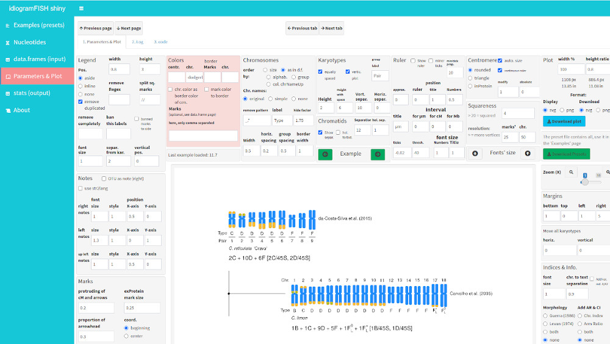

# 3 Minimal Examples

[https://ferroao.gitlab.io/idiogramfishhelppages](https://ferroao.gitlab.io/idiogramfishhelppages/#minimal-examples)

Jupyter interactive version:

[figure not shown]

[Github](https://github.com/fernandoroa/IFjupyter/blob/main/03-minimal.ipynb)

[Raw](https://github.com/fernandoroa/IFjupyter/raw/main/03-minimal.ipynb)

# 4 Plotting chromosomes

[https://ferroao.gitlab.io/idiogramfishhelppages](https://ferroao.gitlab.io/idiogramfishhelppages/#plotting-chromosomes)

Jupyter interactive version:

[figure not shown]

[Github](https://github.com/fernandoroa/IFjupyter/blob/main/04-plotting.ipynb)

[Raw](https://github.com/fernandoroa/IFjupyter/raw/main/04-plotting.ipynb)

# 5 Several OTUs

[https://ferroao.gitlab.io/idiogramfishhelppages](https://ferroao.gitlab.io/idiogramfishhelppages/#multiple-otus)

Jupyter interactive version:

[figure not shown]

[Github](https://github.com/fernandoroa/IFjupyter/blob/main/05-multiple.ipynb)

[Raw](https://github.com/fernandoroa/IFjupyter/raw/main/05-multiple.ipynb)

# 6 Changing Units

[https://ferroao.gitlab.io/idiogramfishhelppages](https://ferroao.gitlab.io/idiogramfishhelppages/#changing-units)

Jupyter interactive version:

[figure not shown]

[Github](https://github.com/fernandoroa/IFjupyter/blob/main/06-units.ipynb)

[Raw](https://github.com/fernandoroa/IFjupyter/raw/main/06-units.ipynb)

# 7 GISH

[https://ferroao.gitlab.io/idiogramfishhelppages](https://ferroao.gitlab.io/idiogramfishhelppages/#gish)

Jupyter interactive version:

[figure not shown]

[Github](https://github.com/fernandoroa/IFjupyter/blob/main/07-gish.ipynb)

[Raw](https://github.com/fernandoroa/IFjupyter/raw/main/07-gish.ipynb)

# 8 Using groups

[https://ferroao.gitlab.io/idiogramfishhelppages](https://ferroao.gitlab.io/idiogramfishhelppages/#groups)

Jupyter interactive version:

[figure not shown]

[Github](https://github.com/fernandoroa/IFjupyter/blob/main/08-groups.ipynb)

[Raw](https://github.com/fernandoroa/IFjupyter/raw/main/08-groups.ipynb)

# 9 Circular plots

[https://ferroao.gitlab.io/idiogramfishhelppages](https://ferroao.gitlab.io/idiogramfishhelppages/#circular-plots)

Jupyter interactive version:

[figure not shown]

[Github](https://github.com/fernandoroa/IFjupyter/blob/main/09-circular.ipynb)

[Raw](https://github.com/fernandoroa/IFjupyter/raw/main/09-circular.ipynb)

# 10 Plotting alongside phylogeny

[https://ferroao.gitlab.io/idiogramfishhelppages](https://ferroao.gitlab.io/idiogramfishhelppages/#plotting-alongside-phylogeny)

Jupyter interactive version:

[figure not shown]

[Github](https://github.com/fernandoroa/IFjupyter/blob/main/10-phylogeny.ipynb)

[Raw](https://github.com/fernandoroa/IFjupyter/raw/main/10-phylogeny.ipynb)

# 11 *Citrus*

[https://ferroao.gitlab.io/idiogramfishhelppages](https://ferroao.gitlab.io/idiogramfishhelppages/#citrus)

Jupyter interactive version:

[figure not shown]

[Github](https://github.com/fernandoroa/IFjupyter/blob/main/11-citrushelp.ipynb)

[Raw](https://github.com/fernandoroa/IFjupyter/raw/main/11-citrushelp.ipynb)

# 12 Human karyotype

[https://ferroao.gitlab.io/idiogramfishhelppages](https://ferroao.gitlab.io/idiogramfishhelppages/#human-karyotype)

Jupyter interactive version:

[figure not shown]

[Github](https://github.com/fernandoroa/IFjupyter/blob/main/12-human.ipynb)

[Raw](https://github.com/fernandoroa/IFjupyter/raw/main/12-human.ipynb)

# 13 Functions

[https://ferroao.gitlab.io/idiogramfishhelppages](https://ferroao.gitlab.io/idiogramfishhelppages/#functions)

# 14 Datasets

[https://ferroao.gitlab.io/idiogramfishhelppages](https://ferroao.gitlab.io/idiogramfishhelppages/#datasets)

# News

[https://ferroao.gitlab.io/idiogramfishhelppages](https://ferroao.gitlab.io/idiogramfishhelppages/#news)

# References

Guerra M. 1986. Reviewing the chromosome nomenclature of Levan et al. *Brazilian Journal of Genetics*, 9(4): 741–743

Levan A, Fredga K, Sandberg AA. 1964. Nomenclature for centromeric position on chromosomes *Hereditas*, 52(2): 201–220. https://doi.org/10.1111/j.1601-5223.1964.tb01953.x

Romero-Zarco C. 1986. A new method for estimating karyotype asymmetry *Taxon*, 35(3): 526–530. https://doi.org/10.2307/1221906

Watanabe K, Yahara T, Denda T, Kosuge K. 1999. Chromosomal evolution in the genus Brachyscome (Asteraceae, Astereae): statistical tests regarding correlation between changes in karyotype and habit using phylogenetic information *Journal of Plant Research*, 112: 145–161. https://link.springer.com/article/10.1007/PL00013869

## R-packages

Csárdi G. 2017. *Crayon: Colored terminal output*. R package version 1.3.4. https://CRAN.R-project.org/package=crayon

Kassambara A. 2019. *Ggpubr: ’ggplot2’ based publication ready plots*. R package version 0.2.3. https://CRAN.R-project.org/package=ggpubr

R Core Team. 2019. *R: A language and environment for statistical computing* R Foundation for Statistical Computing, Vienna, Austria. https://www.R-project.org/

Revell LJ. 2012. Phytools: An r package for phylogenetic comparative biology (and other things). *Methods in Ecology and Evolution*, 3: 217–223. https://doi.org/10.1111/j.2041-210X.2011.00169.x

Roa F, PC Telles M. 2021. *idiogramFISH: Shiny app. Idiograms with marks and karyotype indices* Universidade Federal de Goiás, UFG, Goiânia. R-package. version 2.0.0. https://doi.org/10.5281/zenodo.3579417. https://ferroao.gitlab.io/manualidiogramfish/

Wickham H. 2011. The split-apply-combine strategy for data analysis *Journal of Statistical Software*, 40(1): 1–29. https://www.jstatsoft.org/article/view/v040i01

Wickham H. 2016. *ggplot2: Elegant graphics for data analysis* Springer-Verlag New York. https://ggplot2.tidyverse.org

Wickham H, François R, Henry L, Müller K. 2019. *Dplyr: A grammar of data manipulation*. R package version 0.8.3. https://CRAN.R-project.org/package=dplyr

Wickham H, Henry L. 2020. *Tidyr: Tidy messy data*. R package version 1.0.2. https://CRAN.R-project.org/package=tidyr

Winter DJ. 2017. rentrez: An r package for the NCBI eUtils API *The R Journal*, 9: 520–526

Yu G, Lam TT-Y, Zhu H, Guan Y. 2018. Two methods for mapping and visualizing associated data on phylogeny using ggtree. *Molecular Biology and Evolution*, 35: 3041–3043. https://doi.org/10.1093/molbev/msy194. https://doi.org/10.1093/molbev/msy194

## Shiny App

Bihorel S. 2021. *Rclipboard: Shiny/r wrapper for clipboard.js*. R package version 0.1.3. https://github.com/sbihorel/rclipboard/

Chang W, Borges Ribeiro B. 2018. *Shinydashboard: Create dashboards with shiny*. R package version 0.7.1. http://rstudio.github.io/shinydashboard/

Chang W, Cheng J, Allaire J, Sievert C, Schloerke B, Xie Y, Allen J, McPherson J, Dipert A, Borges B. 2021. *Shiny: Web application framework for r*. R package version 1.6.0. https://shiny.posit.co/

Owen J. 2018. *Rhandsontable: Interface to the handsontable.js library*. R package version 0.3.7. http://jrowen.github.io/rhandsontable/

Warnes GR, Bolker B, Lumley T. 2020. *Gtools: Various r programming tools*. R package version 3.8.2. https://github.com/r-gregmisc/gtools

## Documentation

Barnier J. 2020. *Rmdformats: HTML output formats and templates for ’rmarkdown’ documents*. R package version 0.3.7. https://CRAN.R-project.org/package=rmdformats

Temple Lang D, CRAN team the. 2019. *RCurl: General network (HTTP/FTP/...) Client interface for r*. R package version 1.95-4.12. https://CRAN.R-project.org/package=RCurl

Wickham H, Bryan J. 2019. *Usethis: Automate package and project setup*. R package version 1.5.1. https://CRAN.R-project.org/package=usethis

Wickham H, Danenberg P, Eugster M. 2018. *roxygen2: In-line documentation for r*. R package version 6.1.1. https://CRAN.R-project.org/package=roxygen2

Wickham H, Hesselberth J. 2019. *Pkgdown: Make static HTML documentation for a package*. R package version 1.4.1. https://CRAN.R-project.org/package=pkgdown

Xie Y. 2015. *Dynamic documents with R and knitr* Chapman; Hall/CRC, Boca Raton, Florida. ISBN 978-1498716963. https://yihui.org/knitr/

Xie Y. 2016. *Bookdown: Authoring books and technical documents with R markdown* Chapman; Hall/CRC, Boca Raton, Florida. ISBN 978-1138700109. https://github.com/rstudio/bookdown

Xie Y, Allaire JJ, Grolemund G. 2018. *R markdown: The definitive guide* Chapman; Hall/CRC, Boca Raton, Florida. ISBN 9781138359338. https://bookdown.org/yihui/rmarkdown

Yu G. 2019b. *Badger: Badge for r package*. R package version 0.0.6. https://CRAN.R-project.org/package=badger

Yu G. 2019a. *Rvcheck: R/package version check*. R package version 0.1.6. https://CRAN.R-project.org/package=rvcheck

Zhu H. 2019. *kableExtra: Construct complex table with ’kable’ and pipe syntax*. R package version 1.1.0. https://CRAN.R-project.org/package=kableExtra